# 705604096_stats101b_hw2

Jade Gregory

2023-08-24

## Question 1

```r
idat <- read.csv("101bislandhw2.csv", header = TRUE)
idat
```

```
##    gender             name age vocal_frequency_before vocal_frequency_after
## 1  female      Sarah Bager  92                    205                   280
## 2  female      Helga Thorn 102                    186                   254
## 3  female      Anika Olsen  24                    183                   240
## 4  female   Tindra Landvik  22                    195                   259
## 5  female      Summer Sato   8                    248                   346
## 6  female      Krista Mohr  16                    205                   220
## 7  female Gabrielle Larsen  68                    200                   272
## 8  female  Sakura McCarthy  43                    174                   243
## 9  female    Kirsten Wolff  29                    192                   262
## 10 female Vanessa Sorensen  65                    195                   268
## 11 female Rosemarie Kramer  10                    248                   351
## 12 female     Sonja Jensen  27                    181                   225
## 13 female     Nicole Brown  29                    191                   262
## 14 female     Tineka Thorn  38                    186                   257
## 15 female       Pia Kapoor   8                    241                   320
## 16 female     Kelda Eklund  11                    260                   318
## 17 female   Ariane Baumann  30                    183                   242
## 18 female      Charu Datta   7                    235                   297
## 19 female    Summer Yamada  21                    188                   255
## 20 female      Kana Morris 120                    197                   271
## 21 female      Ciara Jones  22                    174                   259
## 22 female   Viktoria Ibsen  21                    187                   258
## 23 female      Sacha Ibsen  68                    194                   256
## 24 female    Elena Solberg  12                    231                   308
```

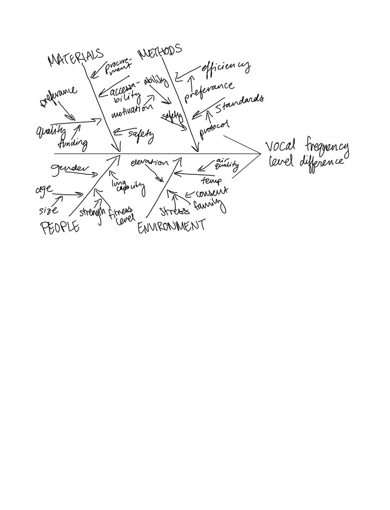

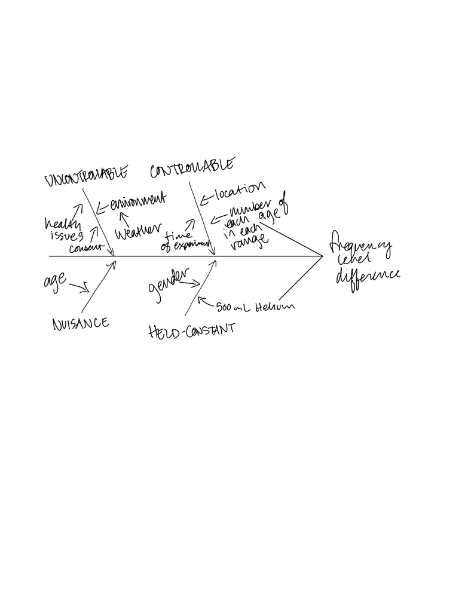

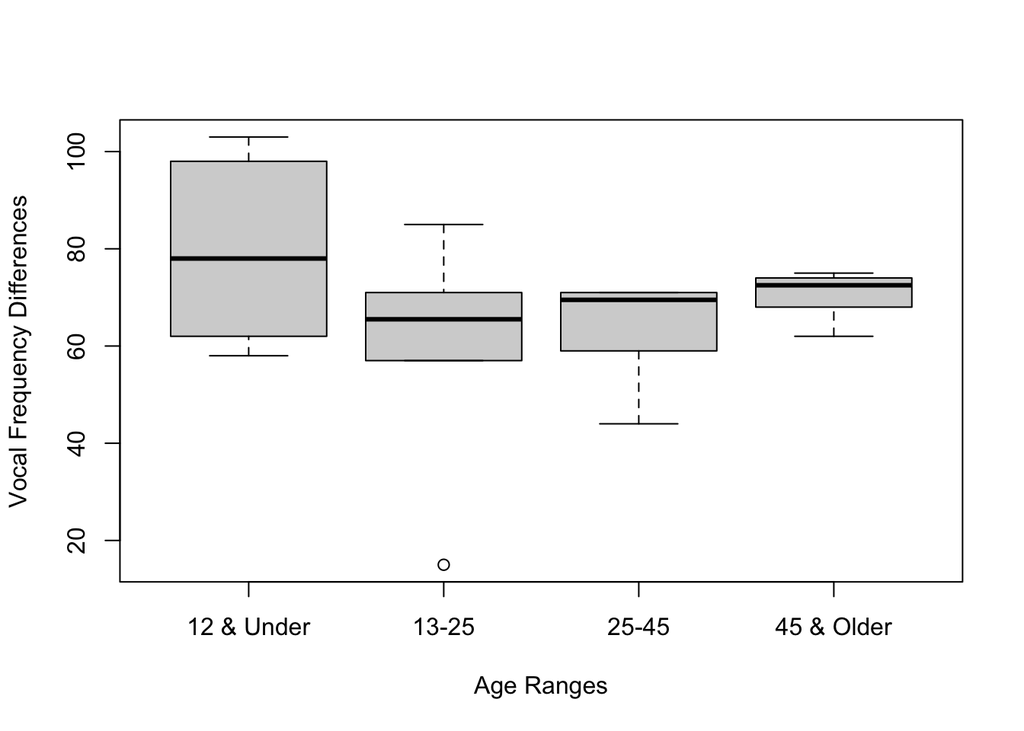

```r
idat$difference <- idat$vocal_frequency_after - idat$vocal_frequency_before
idat$agerange <- cut(idat$age, breaks = c(0, 12, 25, 45, Inf), labels = c("12 & Under", "13-25", "25-45", "45 & Older"))
boxplot(idat$difference ~ idat$agerange, xlab = "Age Ranges", ylab = "Vocal Frequency Differences")
```

This plot shows us that the means of each respective age range are relatively similar. This could indicate that the age range brackets do not have a significant effect on the vocal frequency difference in this experiment. For our 12 & Under age group, we see that the vocal frequency difference has a larger range of values than our older groups of ages. It appears that the oldest age range, 45 & Older, has the smallest range of values for vocal frequency difference.

```r
idataov <- aov(difference ~ agerange, data = idat)
summary(idataov)
```

```
##             Df Sum Sq Mean Sq F value Pr(>F)
## agerange     3   1326   442.1   1.695    0.2
## Residuals   20   5218   260.9
```

Our p-value is 0.2 which is greater than our significance level of 0.05 so we fail to reject the null hypothesis stating that there is no significant difference in the means of the age ranges. Therefore, we can conclude that there is evidence to support the idea that age range does not affect vocal frequency difference in our data.

## Question 2

```r
df_er <- 19 - 3
ss_er <- 196.04 - 36.15
ms_fac <- 36.15 / 3
ms_er <- ss_er / df_er
f <- ms_fac / ms_er
print(c(df_er, ss_er, ms_fac, ms_er, f))
```

```
## [1]  16.000000 159.890000  12.050000   9.993125   1.205829
```

```r
p <- 0.339533
```

DF Error = 16 SS Error = 159.89 MS Factor = 12.05 MS Error = 9.993125 F = 1.205829 P = 0.339533

## Question 3

```r
q3dat <- read.csv("HW2 Q3 Data Su C 2023.csv", header = TRUE)
q3aov <- aov(values ~ ind, data = stack(q3dat))
summary(q3aov)
```

```
##             Df Sum Sq Mean Sq F value Pr(>F)
## ind          3  10.04   3.348   1.298  0.281
## Residuals   76 196.03   2.579
```

Since our p-value of 0.281 is greater than our significance level of 0.05, we fail to reject the null hypothesis stating there is no difference in the means of the different factor levels. So, we can conclude that there is no evidence to support a claim that PEMF usage affects BMD loss.

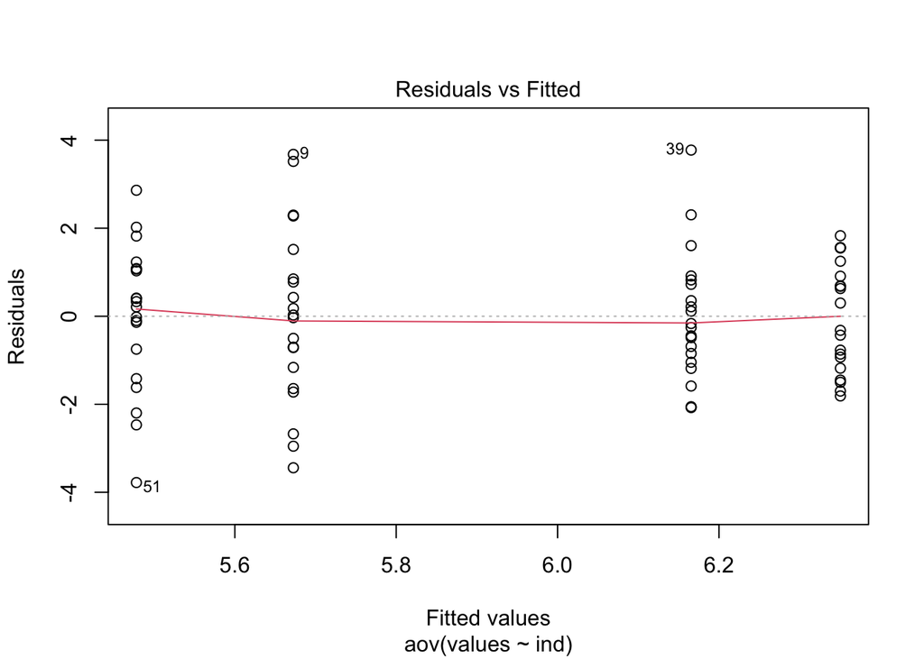

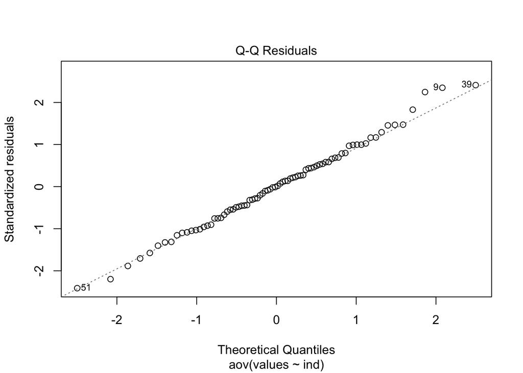

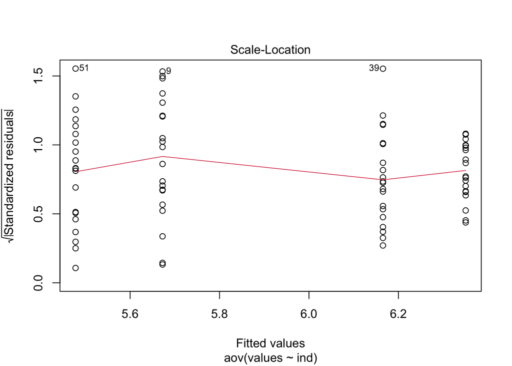

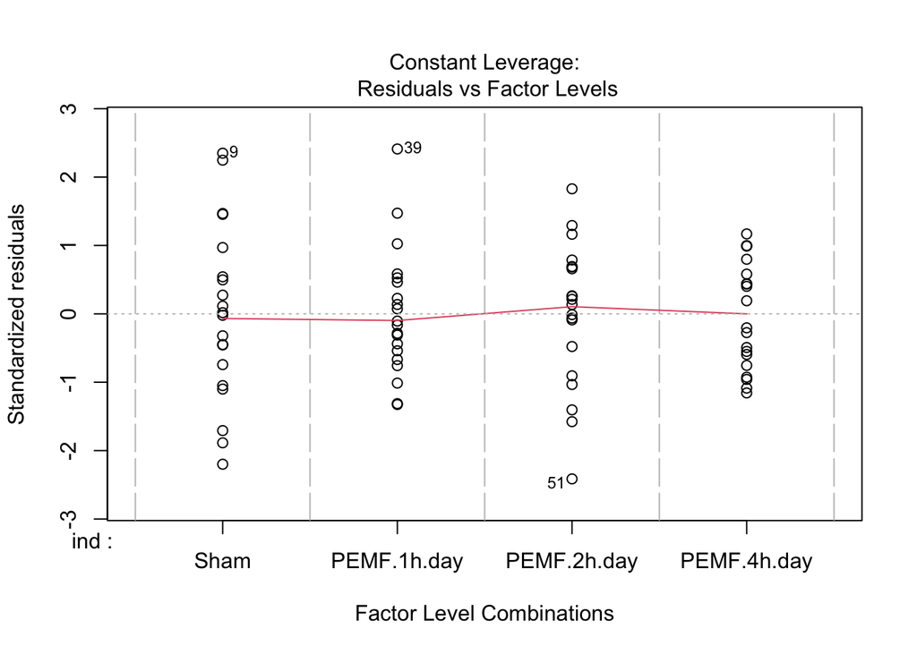

```r
plot(q3aov)
```

In our residuals vs fitted plot, we can see our data points are plotted equally and horizontally across the graph with no noticeable trend supporting the idea that the constant variance assumption is held by our model. In our QQ norm plot we observe that the data points tightly follow the dashed line and do not often stray suggesting that our model holds the normality assumption. In our scale location plot our data points are plotted horizontally across the graph with no noticeable pattern further supporting the idea that our constant variance assumption is held by our model. In our residuals vs factor levels plot, we can see that the data points are plotted equally and horizontally across the graph supporting the idea that our model appropriately accounts for the contribution of each factor level in it. Overall, I believe it is safe to conclude that our model is a great fit for our data based off of these graphs.

## Question 4

```r
cotdat <- read.csv("HW2 Q4 data Su C 2023.csv", header = TRUE)
cotdat$CottonWeight <- as.factor(cotdat$CottonWeight)
cdataov <- aov(Observations ~ CottonWeight, data = cotdat)
summary(cdataov)
```

```
##              Df Sum Sq Mean Sq F value   Pr(>F)
## CottonWeight  4  475.8  118.94   14.76 9.13e-06 ***
## Residuals    20  161.2    8.06
## ---
## Signif. codes:  0 '***' 0.001 '**' 0.01 '*' 0.05 '.' 0.1 ' ' 1
```

With a p-value of 9.13e-06 which is less than our significance level of 0.05, we reject our null hypothesis and can conclude that there is evidence to support the claim that cotton contents appear to have an effect on the mean tensile strength.

```r
#installing packages
install.packages("agricolae")
```

```
## Error in contrib.url(repos, "source"): trying to use CRAN without setting a mirror
```

```r
library(agricolae)
```

```r
print(LSD.test(cdataov, "CottonWeight"))
```

```
## $statistics
##   MSerror Df  Mean       CV  t.value      LSD
##      8.06 20 15.04 18.87642 2.085963 3.745452
##
## $parameters
##         test p.ajusted       name.t ntr alpha
##   Fisher-LSD      none CottonWeight   5  0.05
##
## $means
##    Observations      std r       se       LCL      UCL Min Max Q25 Q50 Q75
## 15          9.8 3.346640 5 1.269646  7.151566 12.44843   7  15   7   9  11
## 20         15.4 3.130495 5 1.269646 12.751566 18.04843  12  18  12  17  18
## 25         17.6 2.073644 5 1.269646 14.951566 20.24843  14  19  18  18  19
## 30         21.6 2.607681 5 1.269646 18.951566 24.24843  19  25  19  22  23
## 35         10.8 2.863564 5 1.269646  8.151566 13.44843   7  15  10  11  11
##
## $comparison
## NULL
##
## $groups
##    Observations groups
## 30         21.6      a
## 25         17.6      b
## 20         15.4      b
## 35         10.8      c
## 15          9.8      c
##
## attr(,"class")
## [1] "group"
```

From our Fisher LSD test we can see that 15% cotton and 35% cotton do not have significantly different mean observations. We also see that 20% cotton and 25% cotton do not have significantly different mean observations, while the rest do have significantly different mean observation values.

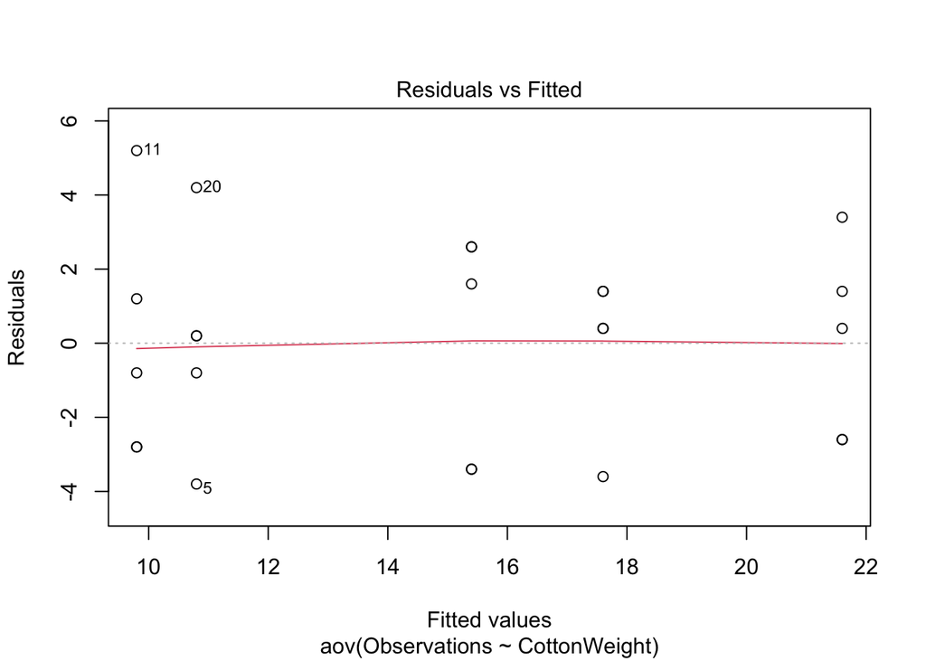

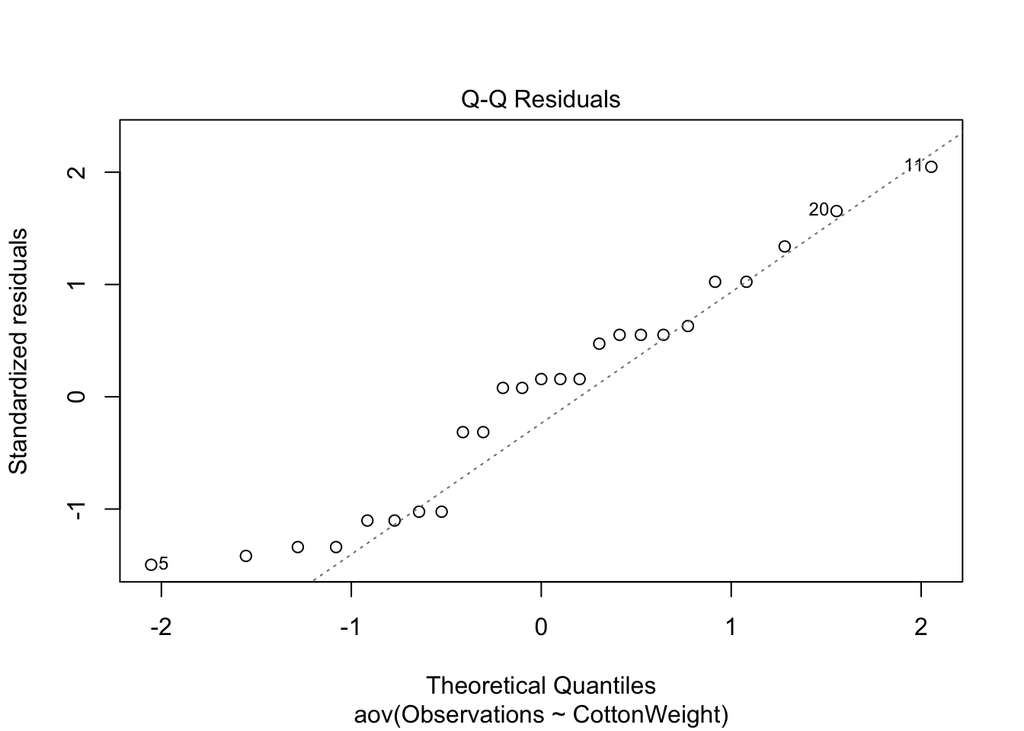

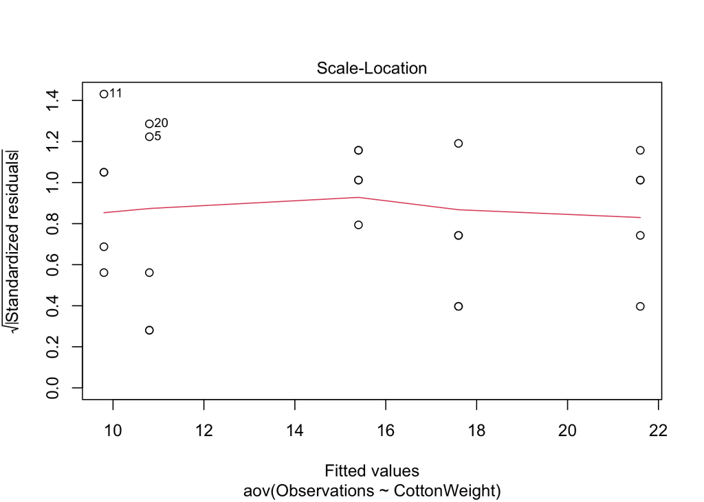

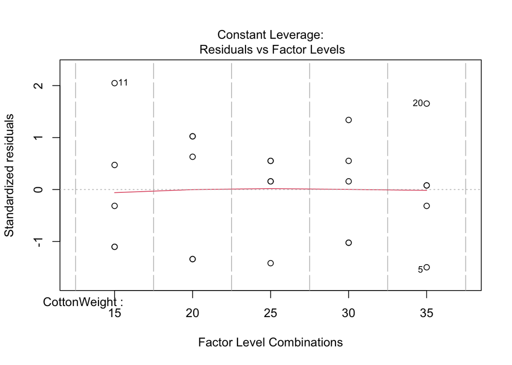

```r
plot(cdataov)
```

In our residuals vs fitted plot, we can see that our data points are plotted randomly and horizontally across the graph. This supports the idea that the constant variance assumption is held by our model. There may be a parabola like pattern that appears to some, but more data would be needed to be sure. If this is the case, it could potentially affect the constant variance assumption of our model. Our QQ norm plot displays our data points as following the dashed line, though they are not extremely tight to the dashed line they do not stray far from it therefore indicating that our normality assumption is held in our model. Our scale location plot displays out data points plotted equally and horizontally across the graph indicating that our constant variance assumption is held by our model. The residuals vs factor levels graph has our data points plotted equally across the graph indicating that our model accurately accounts for the contribution of each factor level in our model. Overall, I would support the idea that this model is a good fit for our data.